# Thesis

# Import data from DIMA

```r
library(tidyverse)
library(gridExtra)
```

# Let try some old fashioned indicator reports!

```r
lpi.data <-read.csv("C:/Users/Alex/Documents/UI/Thesis/Data/Indicator_report_all.csv", header = T)

trmt.join <- read.csv("C:/Users/Alex/Documents/UI/Thesis/Data/trmt_join.csv", header = T) # this has useful info like ecosite and treatment type

# this has plot info like precip
tblplots <- read.csv("C:/Users/Alex/Documents/UI/Thesis/Data/tblPlots.csv", header = T)

# join plot definition to treatment data -need to rename Plot field to PlotID
names(lpi.data)[2] <- "PlotID"
names(trmt.join)[4] <- "PlotID"

# Join of lpi data with treatment data from gis
lpi.trmt <- inner_join(lpi.data, trmt.join, by ="PlotID")
# Replace null with non treatment
lpi.trmt$TRTMNT_1_2 <- gsub("<Null>", "Non Treatment", lpi.trmt$TRTMNT_1_2)
lpi.trmt$TRTMNT_1_2 <- as.factor(lpi.trmt$TRTMNT_1_2)

# subset of data looking at only teb, and discing
narrow.data <- subset(lpi.trmt, lpi.trmt$TRTMNT_1_2 == "Disc & seed" | lpi.trmt$TRTMNT_1_2 == "Tebuthiuron" | lpi.trmt$TRTMNT_1_2 == "Non Treatment")
```

# subset and plot stuff - this plots all the combinations of treatments tyes and ecological sites

for (var1 in unique(narrow.data$Indicator)) { for (var2 in unique(narrow.data$Ecol_Site)) { print(ggplot(data = subset(narrow.data, narrow.data$Indicator == var1 & narrow.data$Ecol_Site == var2), aes(x = Ecol_Site, y = Any.Hit.Avg, fill = TRTMNT_1_2)) + geom_boxplot() + theme_classic() + labs(x = var2, y = var1)) } }

# IF WE FORGET ABOUT ECOLOGICAL SITES

for (var1 in unique(lpi.trmt$Indicator)) { print(ggplot(data = subset(narrow.data, narrow.data$Indicator == var1), aes(x = TRTMNT_1_2, y = Any.Hit.Avg, fill = TRTMNT_1_2 )) + geom_boxplot(alpha = 0.4) + theme_classic() + labs(x = “Treatment Type”, y = var1) + guides(fill=FALSE)) }

# now the same but with facet instead of for

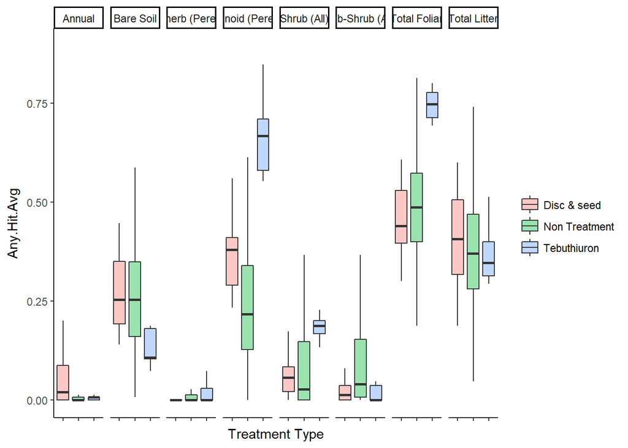

```r
g <- ggplot(data = narrow.data, aes(x = TRTMNT_1_2, y = Any.Hit.Avg, fill = TRTMNT_1_2 )) + geom_boxplot(alpha = 0.4, outlier.shape = NA) + theme_classic() + labs(x = "Treatment Type") + facet_grid(.~Indicator, scales = "free_y") + theme(legend.title=element_blank(), axis.text.x = element_blank())
g
```

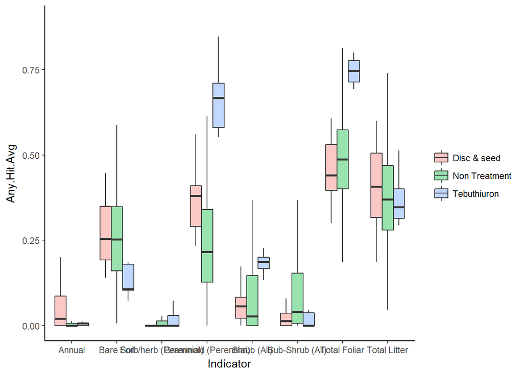

```r
# SIMILAR BUT WITHOUT FACETING
h <- ggplot(data = narrow.data, aes(x = Indicator, y = Any.Hit.Avg, fill = TRTMNT_1_2 )) + geom_boxplot(alpha = 0.4, outlier.shape = NA) + theme_classic() + labs(x = "Indicator") + theme(legend.title=element_blank())
h
```

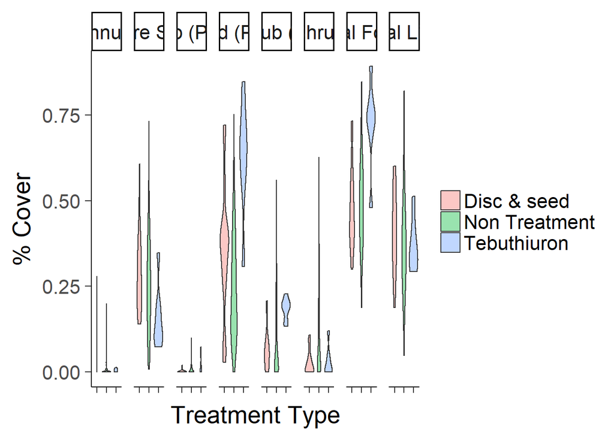

```r
# same thing with violins
j <- ggplot(data = narrow.data, aes(x = TRTMNT_1_2, y = Any.Hit.Avg, fill = TRTMNT_1_2 )) + theme_classic(base_size = 20) + labs(x = "Treatment Type", y = "% Cover") + facet_grid(.~Indicator, scales = "free_y") + theme(legend.title=element_blank(), axis.text.x = element_blank())
j <- j + geom_violin(alpha = 0.4) # need to use colour instead of fill with points
j
```

```r
# lets summarise the data
summary <- lpi.trmt %>%
   group_by(Indicator, Ecol_Site, TRTMNT_1_2) %>%
   summarise(Mean = mean(Any.Hit.Avg), StDev = sd(Any.Hit.Avg), max = max(Any.Hit.Avg), min = min(Any.Hit.Avg))

baseline.summary <- subset(summary, summary$TRTMNT_1_2 == "Non Treatment")

bg <- subset(summary, summary$Indicator == "Bare Soil")

# making it long ???
baseline.long<-baseline.summary %>%
  gather(Stat, Value, 3:4)
```